# Validation experiments

ST310

## Choose one of these datasets

```r
library(modeldata)
data("attrition")
# in console: View(attrition)
dim(attrition) # observations, variables
```

```
## [1] 1470   31
```

```r
library(AppliedPredictiveModeling)
data("permeability")
head(permeability) # numeric outcome
```

```
##   permeability
## 1       12.520
## 2        1.120
## 3       19.405
## 4        1.730
## 5        1.680
## 6        0.510
```

```r
length(permeability) # n
```

```
## [1] 165
```

```r
fingerprints %>% dim() # n by p
```

```
## [1]  165 1107
```

```r
library(caret)
data("cox2")
head(cox2Class) # binary outcome
```

```
## [1] Inactive Inactive Inactive Inactive Inactive Inactive
## Levels: Active Inactive
```

```r
length(cox2Class) # n
```

```
## [1] 462
```

```r
dim(cox2Descr) # n by p
```

```
## [1] 462 255
```

#### Preprocess attrition data

```r
x_variables  <- attrition %>%
  dplyr::select(-Attrition)
X <- model.matrix(~. -1, data = x_variables)
Y <- attrition %>% pull(Attrition)
```

Since this dataset has a binary outcome we’ll use penalized logistic regression instead of penalized linear regression, we do this with the `family = "binomial"` option in the `glmnet` function below (ignore this comment if your data has a numeric outcome)

## Split data into training/test sets

#### Use the `sample()` and `setdiff()` functions to split the data into two random subsets

(Why random subsets instead of 1,…k, and k+1,…n?)

```r
n <- length(Y) # nrow(X)
train <- sample(1:n, floor(4*n/5), replace = FALSE)
test <- setdiff(1:n, train)
c(length(train), length(test))
```

```
## [1] 1176  294
```

```r
X_train <- X[train, ]
X_test <- X[test, ]
Y_train <- Y[train]
Y_test <- Y[test]
```

## Regularized regression models

#### Fit models using `glmnet` on the **training data** for lasso and ridge regression (see `?glmnet`)

```r
ridge_fit <- glmnet(X_train,
                    Y_train,
                    family = "binomial",
                    alpha = 0)

lasso_fit <- glmnet(X_train,
                    Y_train,
                    family = "binomial")
```

#### Choose some arbitrary value of `lambda` and check the `coef()` of the resulting models, compare the coefficient estimates between lasso and ridge (hint: check `?coef.glmnet`)

```r
lam <- 1/20
cbind(coef(ridge_fit, s = lam),
      coef(lasso_fit, s = lam))
```

```
## 61 x 2 sparse Matrix of class "dgCMatrix"
##                                             1             1
## (Intercept)                     -3.285237e-01 -1.7936394391
## Age                             -2.012746e-02 -0.0004349585
## BusinessTravelNon-Travel        -5.660620e-01  .
## BusinessTravelTravel_Frequently  4.193209e-01  .
## BusinessTravelTravel_Rarely     -5.412233e-02  .
## DailyRate                       -2.157673e-04  .
## DepartmentResearch_Development  -1.596944e-01  .
## DepartmentSales                  1.525342e-01  .
## DistanceFromHome                 2.270147e-02  .
## Education.L                     -1.306073e-01  .
## Education.Q                     -6.949760e-02  .
## Education.C                     -8.867093e-02  .
## Education^4                      9.555067e-02  .
## EducationFieldLife_Sciences     -1.242128e-01  .
## EducationFieldMarketing          1.852168e-01  .
## EducationFieldMedical           -1.464183e-01  .
## EducationFieldOther             -3.501972e-01  .
## EducationFieldTechnical_Degree   4.710207e-01  .
## EnvironmentSatisfaction.L       -5.717446e-01 -0.0009823077
## EnvironmentSatisfaction.Q        1.302588e-01  .
## EnvironmentSatisfaction.C       -1.276960e-01  .
## GenderMale                       1.847333e-01  .
## HourlyRate                      -7.679082e-04  .
## JobInvolvement.L                -8.816008e-01 -0.0459110505
## JobInvolvement.Q                 1.082427e-01  .
## JobInvolvement.C                 1.232659e-02  .
## JobLevel                        -6.878692e-02  .
## JobRoleHuman_Resources           3.311015e-01  .
## JobRoleLaboratory_Technician     4.758382e-01  .
## JobRoleManager                  -2.248156e-01  .
## JobRoleManufacturing_Director   -2.827567e-01  .
## JobRoleResearch_Director        -3.565986e-01  .
## JobRoleResearch_Scientist       -2.767488e-02  .
## JobRoleSales_Executive           7.489743e-03  .
## JobRoleSales_Representative      7.346290e-01  0.1511665363
## JobSatisfaction.L               -4.780742e-01  .
## JobSatisfaction.Q               -8.767575e-02  .
## JobSatisfaction.C               -8.493995e-02  .
```

[output cut: 8 more lines]

```
## PerformanceRating.Q              1.047696e-01  .
## PerformanceRating.C              1.168339e-01  .
## RelationshipSatisfaction.L      -2.700622e-01  .
## RelationshipSatisfaction.Q       2.641368e-01  .
## RelationshipSatisfaction.C      -1.316198e-01  .
## StockOptionLevel                -1.527341e-01  .
## TotalWorkingYears               -1.934208e-02 -0.0101000657
## TrainingTimesLastYear           -1.008055e-01  .
## WorkLifeBalance.L               -4.460236e-01  .
## WorkLifeBalance.Q                4.674504e-01  .
## WorkLifeBalance.C                1.221627e-01  .
## YearsAtCompany                  -2.348513e-03  .
## YearsInCurrentRole              -4.266484e-02  .
## YearsSinceLastPromotion          7.902040e-02  .
## YearsWithCurrManager            -5.189642e-02 -0.0010940872
```

#### At the same value of `lambda` above, calculate the accuracy of prediction on both training and test data (use mean-squared error for numeric outcome and misclassification rate for binary, use the option `predict(..., type = "class")` for binary outcome)

Training accuracy for ridge

```r
mean(predict(ridge_fit,
        type = "class",
        s = lam,
        newx = X_train) == Y_train)
```

```
## [1] 0.8886054
```

Test accuracy for ridge

```r
mean(predict(ridge_fit,
        type = "class",
        s = lam,
        newx = X_test) == Y_test)
```

```
## [1] 0.8605442
```

Training accuracy for lasso

```r
mean(predict(lasso_fit,
        type = "class",
        s = lam,
        newx = X_train) == Y_train)
```

```
## [1] 0.8426871
```

Test accuracy for lasso

```r
mean(predict(lasso_fit,
        type = "class",
        s = lam,
        newx = X_test) == Y_test)
```

```
## [1] 0.8231293
```

#### Experiment with changing the value of `lambda` in the above code

#### Plot the fitted coefficients as a function of `lambda`

Hint: just `plot()` the model object, or build the plot manually using `tidy` from the `broom` package

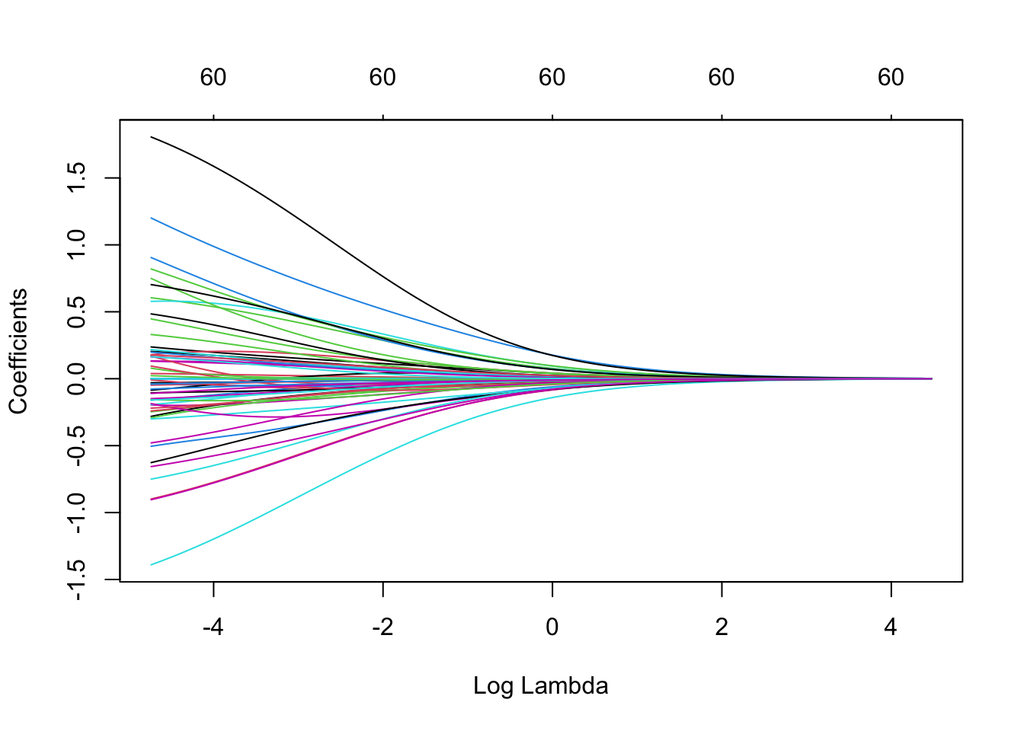

```r
plot(ridge_fit, xvar = "lambda")
```

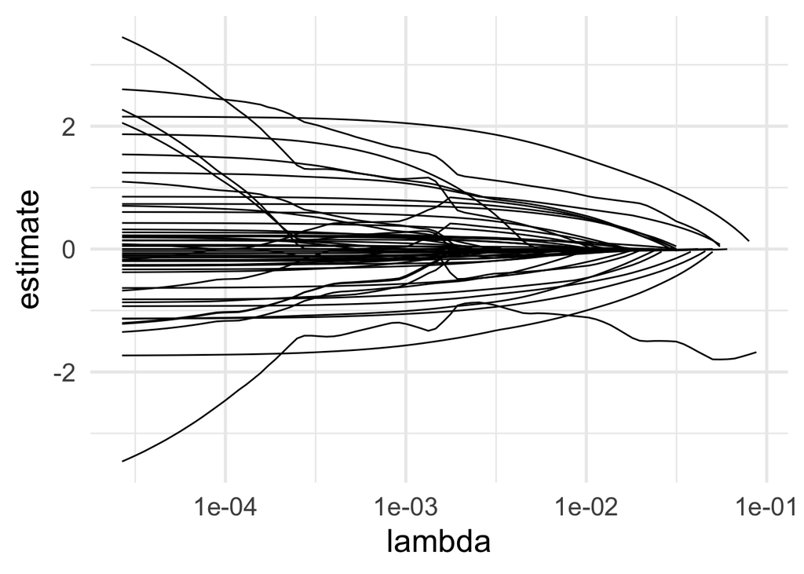

```r
tidy(lasso_fit) %>%
  ggplot(aes(x = lambda, y = estimate, group = term)) +
  geom_line() + scale_x_log10()
```

(Does `glmnet` penalize the intercept term by default?)

#### Plot accuracy on training and test data as a function of `lambda`

Calculating error

```r
yhats_train <- predict(ridge_fit, type = "class", newx = X_train)
yhats_test <- predict(ridge_fit, type = "class", newx = X_test)
plot_data <- data.frame(
  train_error = colMeans(yhats_train != Y_train),
  # or colMeans((yhats_train - Y_train)^2) for numeric outcome
  test_error = colMeans(yhats_test != Y_test),
  lambda = ridge_fit$lambda
)
```

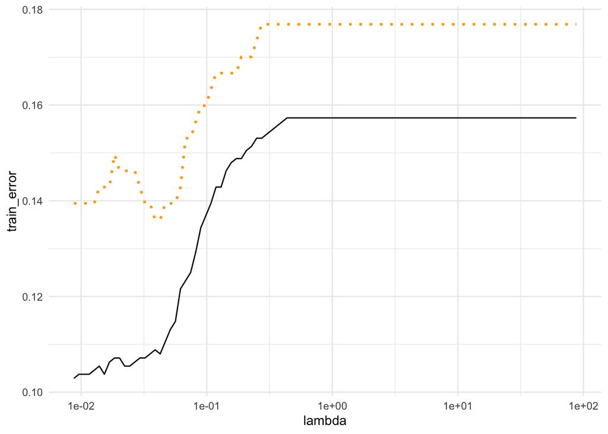

```r
ggplot(plot_data, aes(lambda, train_error)) +
 geom_line() + theme_minimal() +
  geom_line(aes(y = test_error),
            linetype = "dotted",
            color = "orange", size = 1) +
 scale_x_log10()
```

#### Repeat for lasso

```r
yhats_train <- predict(lasso_fit, type = "class", newx = X_train)
yhats_test <- predict(lasso_fit, type = "class", newx = X_test)
plot_data <- data.frame(
  train_error = colMeans(yhats_train != Y_train),
  # or colMeans((yhats_train - Y_train)^2) for numeric outcome
  test_error = colMeans(yhats_test != Y_test),
  lambda = lasso_fit$lambda
)
```

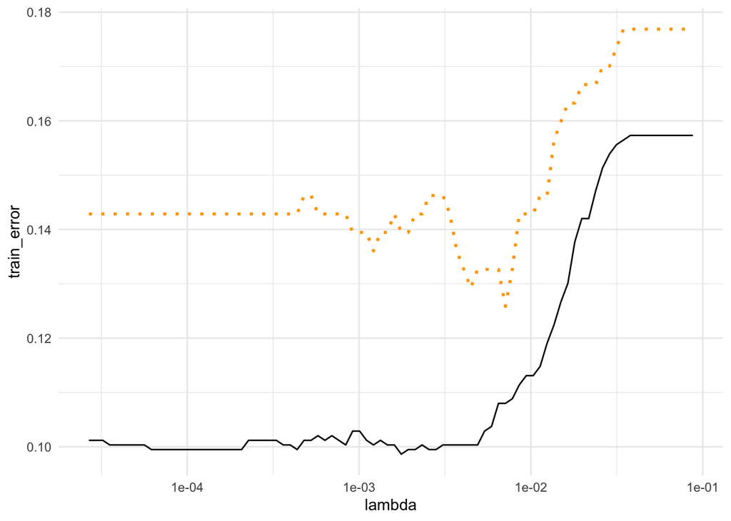

```r
ggplot(plot_data, aes(lambda, train_error)) +
 geom_line() + theme_minimal() +
  geom_line(aes(y = test_error),
            linetype = "dotted",
            color = "orange", size = 1) +
 scale_x_log10()
```

#### What do you notice about these plots? Similarities and differences?

- Test error is almost always higher than training error

#### For lasso, examine `coef()` at the value of `lambda` which minimizes test error

You can roughly guess the value of `lambda` by looking at the plot

```r
beta_hat <- coef(lasso_fit, s = 0.005)
beta_hat
```

```
## 61 x 1 sparse Matrix of class "dgCMatrix"
##                                             1
## (Intercept)                     -1.048341e+00
## Age                             -2.898293e-02
## BusinessTravelNon-Travel        -7.453930e-01
## BusinessTravelTravel_Frequently  5.922182e-01
## BusinessTravelTravel_Rarely      .
## DailyRate                       -1.870960e-04
## DepartmentResearch_Development  -3.622744e-01
## DepartmentSales                  .
## DistanceFromHome                 3.255852e-02
## Education.L                      .
## Education.Q                      .
## Education.C                      .
## Education^4                      7.909684e-02
## EducationFieldLife_Sciences      .
## EducationFieldMarketing          2.870164e-01
## EducationFieldMedical            .
## EducationFieldOther             -8.108256e-02
## EducationFieldTechnical_Degree   6.893367e-01
## EnvironmentSatisfaction.L       -8.616440e-01
## EnvironmentSatisfaction.Q        1.286247e-01
## EnvironmentSatisfaction.C       -1.342159e-01
## GenderMale                       2.154203e-01
## HourlyRate                       .
## JobInvolvement.L                -1.217595e+00
## JobInvolvement.Q                 .
## JobInvolvement.C                 .
## JobLevel                         .
## JobRoleHuman_Resources           3.602178e-01
## JobRoleLaboratory_Technician     7.285439e-01
## JobRoleManager                   .
## JobRoleManufacturing_Director   -1.112049e-01
## JobRoleResearch_Director        -2.987663e-01
## JobRoleResearch_Scientist        .
## JobRoleSales_Executive           .
## JobRoleSales_Representative      1.024338e+00
## JobSatisfaction.L               -6.718845e-01
## JobSatisfaction.Q               -5.130148e-02
## JobSatisfaction.C               -1.663545e-02
```

[output cut: 8 more lines]

```
## PerformanceRating.Q              7.921784e-16
## PerformanceRating.C              6.771713e-16
## RelationshipSatisfaction.L      -3.765244e-01
## RelationshipSatisfaction.Q       3.627974e-01
## RelationshipSatisfaction.C      -1.411428e-01
## StockOptionLevel                -9.544061e-02
## TotalWorkingYears               -4.191800e-02
## TrainingTimesLastYear           -1.224311e-01
## WorkLifeBalance.L               -5.848551e-01
## WorkLifeBalance.Q                6.384085e-01
## WorkLifeBalance.C                7.393478e-02
## YearsAtCompany                   .
## YearsInCurrentRole              -4.993543e-02
## YearsSinceLastPromotion          1.543620e-01
## YearsWithCurrManager            -9.042680e-02
```

What is the sparsity (number/proportion of nonzero coefficients)?

```r
mean(beta_hat[-1] != 0) # -1 to leave out intercept
```

```
## [1] 0.7
```

## Cross-validation

#### Use the `cv.glmnet` function to iterate the above process over several train/test splits and automatically find the value of `lambda` minimizing test accuracy (see `?cv.glmnet`)

Do this for lasso and/or ridge, time permitting

```r
lasso_cv <- cv.glmnet(X_train, Y_train, family = "binomial")
```

#### Compare the values of `lambda.min` and `lambda.1se` (see `?cv.glmnet`)

```r
lmin <- lasso_cv$lambda.min
l1se <- lasso_cv$lambda.1se
c(lmin, l1se)
```

```
## [1] 0.004462589 0.012417419
```

#### Compute the test error accuracy at these two values

Test accuracy for lasso

```r
mean(predict(lasso_fit,
        type = "class",
        s = lmin,
        newx = X_test) == Y_test)
```

```
## [1] 0.8707483
```

```r
mean(predict(lasso_fit,
        type = "class",
        s = l1se,
        newx = X_test) == Y_test)
```

```
## [1] 0.8537415
```

## Reflections

#### Think back on all the results you’ve seen and take notes here

#### Can you think of any questions?